# Un Juego Simple

# Frecuencia de palabras

- Cada miembro del grupo debe seleccionar un texto para analizar (una canción, un poema, el capítulo de un libro, etc.)
- Encuentre la frecuencia de aparición de cada palabra (omita signos de puntuación).
- Construya un diagrama de barras ordenado de mayor a menor frecuencia y compare los resultados obtenidos por cada miembro del grupo
- Interprete los resultados

```python
texto = """
Daría lo que fuera por volverte a ver
Daría hasta mi vida y mi fusil, mis botas y mi fe
Por eso en la trinchera de mi soledad
Tus ojos son mi luz y tu esplendor, mi corazón
Y si no fuera por ti, yo no podría vivir
En el vacío de estos días de no saber
Y si no fuera por ti, yo no sería feliz
Como lo soy cuando con tus besos me veo partir
Y es que sólo con saber
Que al regresar tú esperarás por mí
Aumentan los latidos de mi corazón
Volverte a ver, es todo lo que quiero hacer
Volverte a ver, para poderme reponer
Porque sin ti, mi vida, yo no soy feliz
Porque sin ti, mi vida no tiene raíz
Ni una razón para vivir
Lo único que quiero es poder regresar
Poder todas las balas esquivar y sobrevivir
Tu amor es mi esperanza y tú mi munición
Por eso regresar a ti es mi única misión
Y si no fuera por ti, yo no podría vivir
En el vacío de estos días de no saber
Y si no fuera por ti, yo no sería feliz
Como lo soy cuando con tus besos me veo partir
Y es que sólo con saber
Que al regresar tú esperarás por mí
Aumentan los latidos de mi corazón
Volverte a ver, es todo lo que quiero hacer
Volverte a ver, para poderme reponer
Porque sin ti, mi vida, yo no soy feliz
Porque sin ti, mi vida no tiene raíz
Ni una razón para vivir
Eres todo lo que tengo y no me quiero morir
Sin poder, otra vez, volverte a ver
Porque sin ti, mi vida, yo no soy feliz
Porque sin ti, mi vida no tiene raíz
Volverte a ver, es todo lo que quiero hacer
Volverte a ver, para poderme reponer
Porque sin ti, mi vida, yo no soy feliz
Porque sin ti, mi vida no tiene raíz
Ni una razón para vivir
"""
```

```python
texto2 = """
(Oh-oh)
(Aah)
(Oh-oh)

Don't have to tell your hot ass a thing
Oh, yeah, you just get it (get it)
Whole package, babe, I like the way you fit
God bless your dad's genetics (genetics), mm, uh

You make me wanna make you fall in love
Oh, late at night, I'm thinkin' 'bout you (ah, ah, ah)
Wanna try on my fuzzy pink handcuffs?
Oh, I hear you knockin', baby
Come on up

I know you want my touch for life
If you love me right, then who knows?
I might let you make me Juno
You know I just might
Let you lock me down tonight
One of me is cute, but two, though
Give it to me, baby
You make me wanna make you fall in love (oh)

I showed my friends, then we high-fived (oh-oh)
Sorry if you feel objectified (oh)
Can't help myself, hormones are high
Give me more than just some butterflies

You make me wanna make you fall in love (ooh-ooh)
Oh, late at night, I'm thinkin' 'bout you (ah, ah, ah)
Wanna try on some freaky positions? (Ooh-ooh)
Have you ever tried this one?

I know you want my touch for life
If you love me right, then who knows?
I might let you make me Juno
You know I just might
Let you lock me down tonight
One of me is cute, but two, though
Give it to me, baby
You make me wanna make you fall in love

Adore me, hold me and explore me
Mark your territory
Tell me I'm the only, only, only, only one
Adore me, hold me and explore me
I'm so fuckin' horny
Tell me I'm the only, only, only, only one

Oh, I know you want my touch for life
If you love me right, then who knows?
I might let you make me Juno
You know I just might (might)
Let you lock me down tonight
One of me is cute, but two, though
Give it to me, baby
You make me wanna make you fall in love, oh
"""
```

```python
# Limpiar texto y pasarlo a minusculas
texto_limpio = re.sub(r'[^\w\s]', '', texto.lower())
texto2_limpio = re.sub(r'[^\w\s]', '', texto2.lower())
```

```python
# Lista de palabras
palabras = texto_limpio.split()
palabras2 = texto2_limpio.split()

# Contar la frecuencia de cada palabra
frec = Counter(palabras)
frec2 = Counter(palabras2)
```

[figure not shown]

```python
orderWords = dict(frec.most_common())

# Grafico de barras
plt.figure(figsize=(12, 6))
plt.bar(orderWords.keys(), orderWords.values())
plt.xticks(rotation=90, ha='center', fontsize=10)
plt.xlabel('Palabras', fontsize=12)
plt.ylabel('Frecuencia', fontsize=12)
plt.title('Frecuencia de palabras de volverte a ver de Juanes', fontsize=14)
plt.tight_layout()
plt.show()
```

[figure not shown]

```python
orderWords2 = dict(frec2.most_common())

# Grafico de barras
plt.figure(figsize=(12, 6))
plt.bar(orderWords2.keys(), orderWords2.values())
plt.xticks(rotation=90, ha='center', fontsize=10)
plt.xlabel('Palabras', fontsize=12)
plt.ylabel('Frecuencia', fontsize=12)
plt.title('Frecuencia de palabras de Juno de Sabrina Carpenter', fontsize=14)
plt.tight_layout()
plt.show()
```

- Muchas de las palabras tienen una compañera, es decir, se repiten igual de veces que al menos 1 palabra.
- Las palabras que más se utilizan en la cancion son monosilabas y conectores (mi, no, ti, y, que por, a) (you, me, make, i, oh)
- Un total de 90 palabras (aproximadamente) diferentes son capaces de formar una canción

# Población en las ciudades

- Analice la distribución de las poblaciones en los municipios de Colombia. Puede consultar la información en páginas como: https://www.citypopulation.de/en/colombia/cities/ o similares.
- Realice el mismo ejercicio, pero ahora sobre las poblaciones de los países en América.
- Genere conclusiones a partir de los datos obtenidos.

```python
# URL de la página que contiene la tabla
url = 'https://www.citypopulation.de/en/colombia/admin/'

# Hacer una solicitud GET a la página
response = requests.get(url)

# Verificar que la solicitud fue exitosa
if response.status_code == 200:
    # Parsear el contenido HTML de la página
    soup = BeautifulSoup(response.content, 'html.parser')

    # Encontrar la tabla con la clase "data" y el id "tl"
    table = soup.find('table', {'class': 'data', 'id': 'tl'})

    # Leer la tabla en un DataFrame usando pandas
    df = pd.read_html(str(table))[0]

    # Guardar los datos en un archivo CSV para análisis posterior
    df.to_csv('poblacion_municipios_colombia.csv', index=True)

    # Mostrar un mensaje de éxito
    print("Datos guardados exitosamente en 'poblacion_municipios_colombia.csv'.")
else:
    print(f"Error al acceder a la página: {response.status_code}")
```

```python
df.rename(columns={'Population Estimate 2005-06-30':'Population_Estimate_2005'}, inplace = True)
df.rename(columns={'Population Estimate 2010-06-30':'Population_Estimate_2010'}, inplace = True)
df.rename(columns={'Population Estimate 2015-06-30':'Population_Estimate_2015'}, inplace = True)
df.rename(columns={'Population Projection 2020-06-30':'Population_Projection_2020'}, inplace = True)
df.head()
```

|  | Name | Status | Population_Estimate_2005 | Population_Estimate_2010 | Population_Estimate_2015 | Population_Projection_2020 | Unnamed: 6 |
| --- | --- | --- | --- | --- | --- | --- | --- |
| 0 | Amazonas | Department | 47830 | 56747 | 67862 | 80472 | → |
| 1 | El Encanto | Area | 3343 | 4026 | 3241 | 2078 | → |
| 2 | La Chorrera | Area | 1562 | 2062 | 2599 | 3040 | → |
| 3 | La Pedrera | Area | 907 | 1149 | 2767 | 3985 | → |
| 4 | La Victoria | Area | 744 | 867 | 552 | 658 | → |

```python
df['Status'].unique()
```

```
array(['Department', 'Area', 'Municipality', 'Capital District',
       'Republic'], dtype=object)
```

```python
df['Name'].unique()
```

```
array(['Amazonas', 'El Encanto', 'La Chorrera', ..., 'La Primavera',
       'Puerto Carreño', 'Santa Rosalía'], dtype=object)
```

```python
# Nombre muy largo
replace_dict = {
    'Archipiélago de San Andrés, Providencia y Santa Catalina': 'Archipielago'
}
df['Name'] = df['Name'].replace(replace_dict)
```

```python
# Filtrar por departamento
dfDepartment = df[df['Status'] == 'Department']

# Ordenar por poblacion
dfDepartmentSort = dfDepartment.sort_values(by='Population_Projection_2020', ascending=False)
```

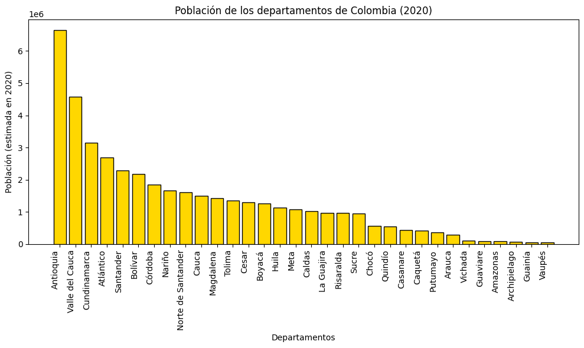

```python
plt.figure(figsize=(10, 6))
plt.bar(dfDepartmentSort['Name'], dfDepartmentSort['Population_Projection_2020'], color='gold', edgecolor='black')
plt.xticks(rotation=90, ha='right')
plt.xlabel('Departamentos')
plt.ylabel('Población (estimada en 2020)')
plt.title('Población de los departamentos de Colombia (2020)')
plt.tight_layout()
plt.show()
```

```python
# URL de la página que contiene la tabla
url = 'https://www.citypopulation.de/en/argentina/admin/'

# Hacer una solicitud GET a la página
response = requests.get(url)

# Verificar que la solicitud fue exitosa
if response.status_code == 200:
    # Parsear el contenido HTML de la página
    soup = BeautifulSoup(response.content, 'html.parser')

    # Encontrar la tabla con la clase "data" y el id "tl"
    table = soup.find('table', {'class': 'data', 'id': 'tl'})

    # Leer la tabla en un DataFrame usando pandas
    dfArg = pd.read_html(str(table))[0]

    # Guardar los datos en un archivo CSV para análisis posterior
    dfArg.to_csv('poblacion_municipios_argentina.csv', index=True)

    # Mostrar un mensaje de éxito
    print("Datos guardados exitosamente en 'poblacion_municipios_argentina.csv'.")
else:
    print(f"Error al acceder a la página: {response.status_code}")
```

```python
dfArg.rename(columns={'Population Census 1991-05-15':'Population_Census_1991'}, inplace = True)
dfArg.rename(columns={'Population Census 2001-11-17':'Population_Census_2001'}, inplace = True)
dfArg.rename(columns={'Population Census 2010-10-27':'Population_Census_2010'}, inplace = True)
dfArg.rename(columns={'Population Census 2022-05-18':'Population_Census_2022'}, inplace = True)
dfArg.head()
```

|  | Name | Status | Population_Census_1991 | Population_Census_2001 | Population_Census_2010 | Population_Census_2022 | Unnamed: 6 |
| --- | --- | --- | --- | --- | --- | --- | --- |
| 0 | Buenos Aires | Province | 12594974 | 13827203 | 15625084 | 17523996 | → |
| 1 | Adolfo Alsina | Partido | 18077 | 16245 | 17072 | 17552 | → |
| 2 | Adolfo Gonzales Chaves | Partido | 12747 | 12037 | 12047 | 12914 | → |
| 3 | Alberti | Partido | 10627 | 10373 | 10654 | 12982 | → |
| 4 | Almirante Brown | Partido | 450698 | 515556 | 552902 | 584827 | → |

```python
dfArg['Status'].unique()
```

```
array(['Province', 'Partido', 'Department', 'Federal District', 'City',
       'Republic'], dtype=object)
```

```python
# Filtrar por departamento
dfDepartmentArg = dfArg[dfArg['Status'] == 'Province']

# Ordenar por poblacion
dfDepartmentSortArg = dfDepartmentArg.sort_values(by='Population_Census_2010', ascending=False)
```

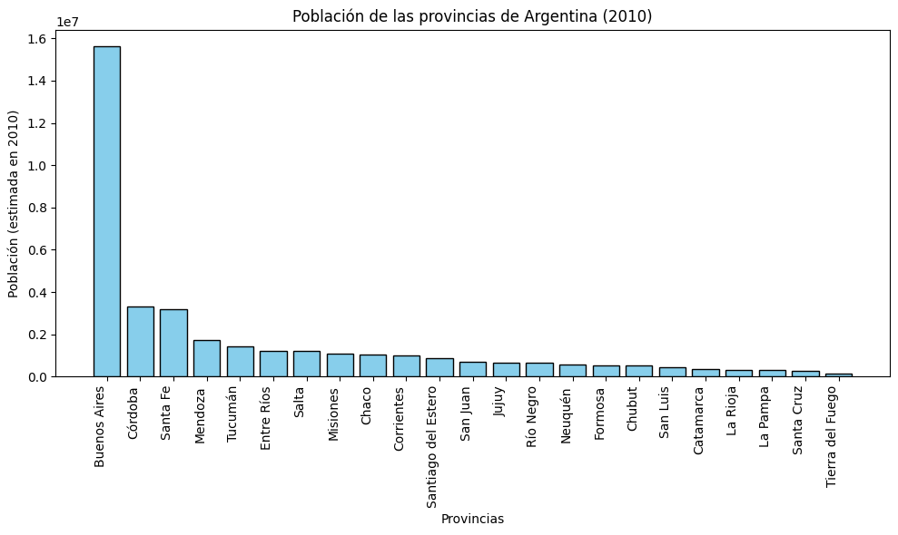

```python
plt.figure(figsize=(10, 6))
plt.bar(dfDepartmentSortArg['Name'], dfDepartmentSortArg['Population_Census_2010'], color='skyblue', edgecolor='black')
plt.xticks(rotation=90, ha='right')
plt.xlabel('Provincias')
plt.ylabel('Población (estimada en 2010)')
plt.title('Población de las provincias de Argentina (2010)')
plt.tight_layout()
plt.show()
```